# LoanTap Business Case

Problem Statement: LoanTap aims to optimize its loan distribution process to ensure funds are allocated to borrowers who are most likely to repay. The eligibility criteria for loan distribution plays a crucial role in achieving this objective. Approach: By analyzing the creditworthiness and financial stability of potential customers, LoanTap can determine eligibility criteria that minimize default risks. This involves evaluating factors such as credit scores, income stability, employment history, and debt-to-income ratio. Implementing stringent eligibility standards ensures loans are disbursed responsibly, mitigating the risk of defaults and enhancing the overall efficiency of the lending process.

## Imported Dependencies

```python
import numpy as np
import pandas as pd
import seaborn as sns
import matplotlib.pyplot as plt
from sklearn.impute import SimpleImputer
from sklearn.preprocessing import LabelEncoder
from sklearn.preprocessing import OneHotEncoder
from sklearn.preprocessing import OrdinalEncoder
from sklearn.model_selection import train_test_split
from sklearn.preprocessing import MinMaxScaler
from sklearn.preprocessing import StandardScaler
from sklearn.linear_model import LogisticRegression
from sklearn.metrics import confusion_matrix
from sklearn.metrics import classification_report
from sklearn.metrics import ConfusionMatrixDisplay
from sklearn.metrics import precision_score
from sklearn.metrics import recall_score
from sklearn.metrics import f1_score
from sklearn.metrics import roc_curve
from sklearn.metrics import roc_auc_score
from sklearn.metrics import precision_recall_curve
from statsmodels.stats.outliers_influence import variance_inflation_factor
from imblearn.over_sampling import SMOTE
from sklearn.metrics import accuracy_score
```

```python
df = pd.read_csv('LoanTap_logistic_regression.csv')
df.head()
```

|  | loan_amnt | term | int_rate | installment | grade | sub_grade | emp_title | emp_length | home_ownership | annual_inc | ... | open_acc | pub_rec | revol_bal | revol_util | total_acc | initial_list_status | application_type | mort_acc | pub_rec_bankruptcies | address |
| --- | --- | --- | --- | --- | --- | --- | --- | --- | --- | --- | --- | --- | --- | --- | --- | --- | --- | --- | --- | --- | --- |
| 0 | 10000.0 | 36 months | 11.44 | 329.48 | B | B4 | Marketing | 10+ years | RENT | 117000.0 | ... | 16.0 | 0.0 | 36369.0 | 41.8 | 25.0 | w | INDIVIDUAL | 0.0 | 0.0 | 0174 Michelle Gateway\r\nMendozaberg, OK 22690 |
| 1 | 8000.0 | 36 months | 11.99 | 265.68 | B | B5 | Credit analyst | 4 years | MORTGAGE | 65000.0 | ... | 17.0 | 0.0 | 20131.0 | 53.3 | 27.0 | f | INDIVIDUAL | 3.0 | 0.0 | 1076 Carney Fort Apt. 347\r\nLoganmouth, SD 05113 |
| 2 | 15600.0 | 36 months | 10.49 | 506.97 | B | B3 | Statistician | < 1 year | RENT | 43057.0 | ... | 13.0 | 0.0 | 11987.0 | 92.2 | 26.0 | f | INDIVIDUAL | 0.0 | 0.0 | 87025 Mark Dale Apt. 269\r\nNew Sabrina, WV 05113 |
| 3 | 7200.0 | 36 months | 6.49 | 220.65 | A | A2 | Client Advocate | 6 years | RENT | 54000.0 | ... | 6.0 | 0.0 | 5472.0 | 21.5 | 13.0 | f | INDIVIDUAL | 0.0 | 0.0 | 823 Reid Ford\r\nDelacruzside, MA 00813 |
| 4 | 24375.0 | 60 months | 17.27 | 609.33 | C | C5 | Destiny Management Inc. | 9 years | MORTGAGE | 55000.0 | ... | 13.0 | 0.0 | 24584.0 | 69.8 | 43.0 | f | INDIVIDUAL | 1.0 | 0.0 | 679 Luna Roads\r\nGreggshire, VA 11650 |

5 rows × 27 columns

```python
df.shape
```

```
(396030, 27)
```

```python
df.info()
```

```
<class 'pandas.core.frame.DataFrame'>
RangeIndex: 396030 entries, 0 to 396029
Data columns (total 27 columns):
 #   Column                Non-Null Count   Dtype
---  ------                --------------   -----
 0   loan_amnt             396030 non-null  float64
 1   term                  396030 non-null  object
 2   int_rate              396030 non-null  float64
 3   installment           396030 non-null  float64
 4   grade                 396030 non-null  object
 5   sub_grade             396030 non-null  object
 6   emp_title             373103 non-null  object
 7   emp_length            377729 non-null  object
 8   home_ownership        396030 non-null  object
 9   annual_inc            396030 non-null  float64
```

[output cut: 19 more lines]

Given the dataset containing a mixture of 'Numerical' and 'Categorical' data, along with the need to preprocess certain 'Categorical' columns for analysis, an initial step of data extraction and conversion will be conducted to ensure their suitability for further analysis.

```python
df.describe()
```

|  | loan_amnt | int_rate | installment | annual_inc | dti | open_acc | pub_rec | revol_bal | revol_util | total_acc | mort_acc | pub_rec_bankruptcies |
| --- | --- | --- | --- | --- | --- | --- | --- | --- | --- | --- | --- | --- |
| count | 396030.000000 | 396030.000000 | 396030.000000 | 3.960300e+05 | 396030.000000 | 396030.000000 | 396030.000000 | 3.960300e+05 | 395754.000000 | 396030.000000 | 358235.000000 | 395495.000000 |
| mean | 14113.888089 | 13.639400 | 431.849698 | 7.420318e+04 | 17.379514 | 11.311153 | 0.178191 | 1.584454e+04 | 53.791749 | 25.414744 | 1.813991 | 0.121648 |
| std | 8357.441341 | 4.472157 | 250.727790 | 6.163762e+04 | 18.019092 | 5.137649 | 0.530671 | 2.059184e+04 | 24.452193 | 11.886991 | 2.147930 | 0.356174 |
| min | 500.000000 | 5.320000 | 16.080000 | 0.000000e+00 | 0.000000 | 0.000000 | 0.000000 | 0.000000e+00 | 0.000000 | 2.000000 | 0.000000 | 0.000000 |
| 25% | 8000.000000 | 10.490000 | 250.330000 | 4.500000e+04 | 11.280000 | 8.000000 | 0.000000 | 6.025000e+03 | 35.800000 | 17.000000 | 0.000000 | 0.000000 |
| 50% | 12000.000000 | 13.330000 | 375.430000 | 6.400000e+04 | 16.910000 | 10.000000 | 0.000000 | 1.118100e+04 | 54.800000 | 24.000000 | 1.000000 | 0.000000 |
| 75% | 20000.000000 | 16.490000 | 567.300000 | 9.000000e+04 | 22.980000 | 14.000000 | 0.000000 | 1.962000e+04 | 72.900000 | 32.000000 | 3.000000 | 0.000000 |
| max | 40000.000000 | 30.990000 | 1533.810000 | 8.706582e+06 | 9999.000000 | 90.000000 | 86.000000 | 1.743266e+06 | 892.300000 | 151.000000 | 34.000000 | 8.000000 |

```python
df.describe(include='object')
```

|  | term | grade | sub_grade | emp_title | emp_length | home_ownership | verification_status | issue_d | loan_status | purpose | title | earliest_cr_line | initial_list_status | application_type | address |
| --- | --- | --- | --- | --- | --- | --- | --- | --- | --- | --- | --- | --- | --- | --- | --- |
| count | 396030 | 396030 | 396030 | 373103 | 377729 | 396030 | 396030 | 396030 | 396030 | 396030 | 394275 | 396030 | 396030 | 396030 | 396030 |
| unique | 2 | 7 | 35 | 173105 | 11 | 6 | 3 | 115 | 2 | 14 | 48817 | 684 | 2 | 3 | 393700 |
| top | 36 months | B | B3 | Teacher | 10+ years | MORTGAGE | Verified | Oct-2014 | Fully Paid | debt_consolidation | Debt consolidation | Oct-2000 | f | INDIVIDUAL | USCGC Smith\r\nFPO AE 70466 |
| freq | 302005 | 116018 | 26655 | 4389 | 126041 | 198348 | 139563 | 14846 | 318357 | 234507 | 152472 | 3017 | 238066 | 395319 | 8 |

```python
df.duplicated().sum()
```

```
0
```

Here we have no other duplicate values in it

```python
df.isnull().sum()
```

```
loan_amnt                   0
term                        0
int_rate                    0
installment                 0
grade                       0
sub_grade                   0
emp_title               22927
emp_length              18301
home_ownership              0
annual_inc                  0
verification_status         0
issue_d                     0
loan_status                 0
purpose                     0
title                    1755
dti                         0
earliest_cr_line            0
open_acc                    0
pub_rec                     0
revol_bal                   0
revol_util                276
total_acc                   0
initial_list_status         0
application_type            0
mort_acc                37795
pub_rec_bankruptcies      535
address                     0
dtype: int64
```

```python
df['earliest_year'] = df['earliest_cr_line'].str.split('-').str[-1]

df['earliest_year'] = pd.to_numeric(df['earliest_year'])
```

Extracting the year from the 'Earliest Credit Line' column and converting its datatype from 'String' to 'Integer' to create the 'Earliest Credit Line Year' column.

```python
df['pin_code'] = df['address'].str.split(' ').str[-1]
```

Extraction of pincode from the 'Address' column from the Data set

```python
df['issue_d_year'] = df['issue_d'].str.split('-').str[-1]

df['issue_d_year'] = pd.to_numeric(df['issue_d_year'])
```

```python
columns_drop = ['earliest_cr_line', 'address', 'issue_d']
df = df.drop(columns= columns_drop)
```

```python
for column in ('term', 'earliest_year', 'grade', 'sub_grade', 'emp_title', 'emp_length', 'home_ownership', 'verification_status', 'loan_status', 'purpose', 'title', 'initial_list_status', 'application_type', 'pin_code'):
    df[column] = df[column].astype('category')
```

Transforming 'Categorical' data from the 'object' data type to the 'Category' data type.

## Analysis on Univariate with Continous

Univariate analysis of individual columns aids in understanding the data distribution. For 'Categorical' columns, it's crucial to ascertain whether the data exhibits any discernible categorization or if the column comprises random values that offer no actionable insights.

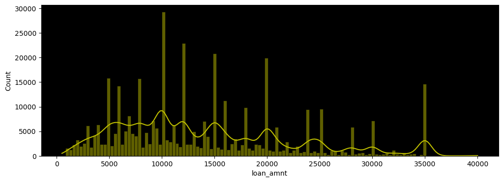

```python
plt.figure(figsize=(12,4))
sns.histplot(df['loan_amnt'],kde=True, color='y');
ax = plt.gca()
ax.set_facecolor("Black")
```

The graph depicts that a significant number of individuals have taken loans of $10,000, which appears to be the most common loan amount. Furthermore, it is evident that loan amounts are distributed across various values, indicating that loans have been taken at almost every value.

```python
continious = df.select_dtypes('float64').columns.tolist()
continious
```

```
['loan_amnt',
 'int_rate',
 'installment',
 'annual_inc',
 'dti',
 'open_acc',
 'pub_rec',
 'revol_bal',
 'revol_util',
 'total_acc',
 'mort_acc',
 'pub_rec_bankruptcies']
```

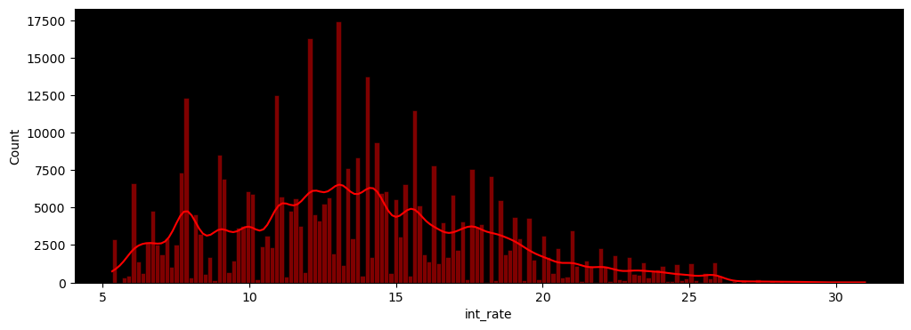

```python
plt.figure(figsize=(12,4))
sns.histplot(df['int_rate'],kde=True, color='r');
ax = plt.gca()
ax.set_facecolor("Black")
```

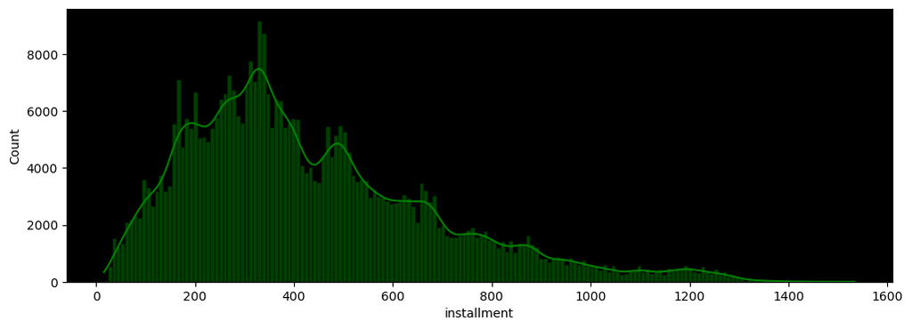

```python
plt.figure(figsize=(12,4))
sns.histplot(df['installment'],kde=True, color='g');
ax = plt.gca()
ax.set_facecolor("Black")
```

The graph represents the monthly installment amounts paid by individuals who have taken out loans. It indicates that the most common installment amounts fall within the range of 300 to 400, with individuals repaying their loan amounts on specified dates throughout the months.

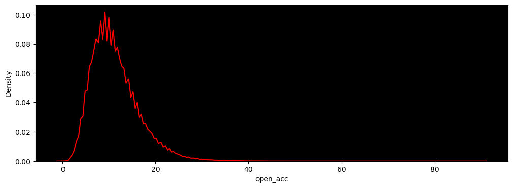

```python
plt.figure(figsize=(12,4))
sns.kdeplot(df['open_acc'], color="red")
ax = plt.gca()
ax.set_facecolor("Black")
```

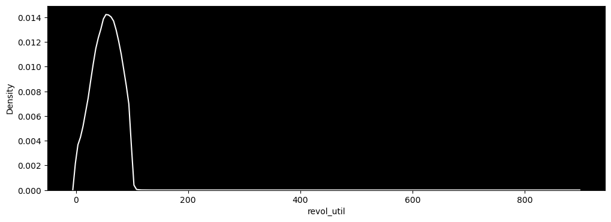

```python
plt.figure(figsize=(12,4))
sns.kdeplot(df['revol_util'], color="white")
ax = plt.gca()
ax.set_facecolor("Black")
```

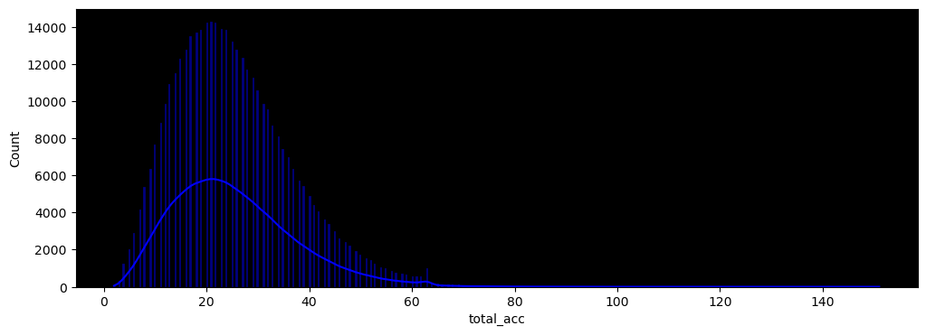

```python
plt.figure(figsize=(12,4))
sns.histplot(df['total_acc'],kde=True, color="blue")
ax = plt.gca()
ax.set_facecolor("Black")
```

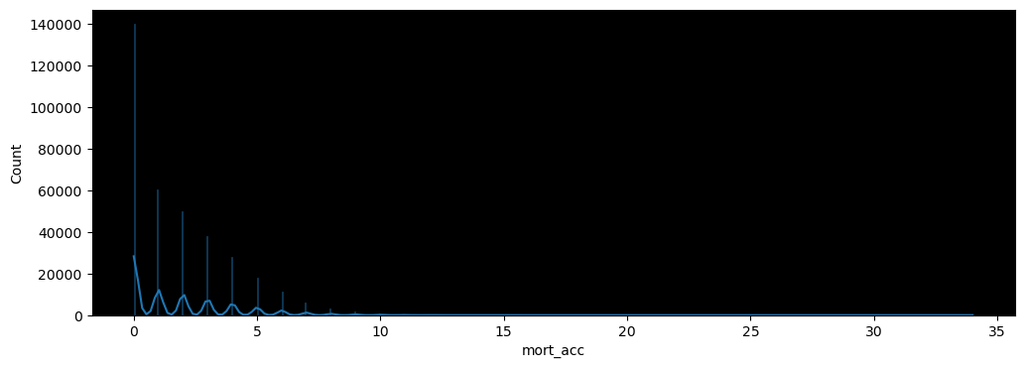

```python
plt.figure(figsize=(12,4))
sns.histplot(df['mort_acc'], kde=True);
ax = plt.gca()
ax.set_facecolor("Black")
```

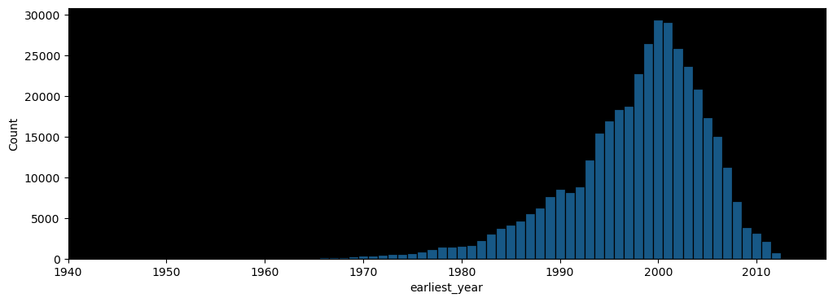

```python
plt.figure(figsize=(12,4))
sns.histplot(df['earliest_year'])
plt.gca().set_facecolor("black")
plt.show()
```

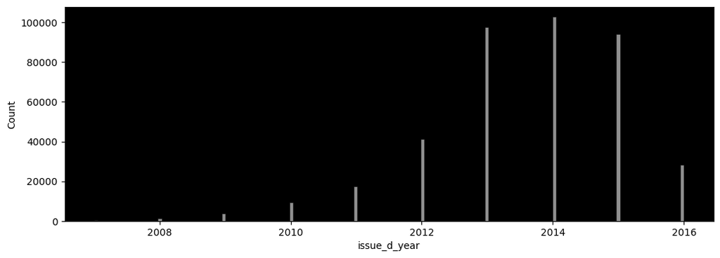

```python
plt.figure(figsize=(12,4))
sns.histplot(df['issue_d_year'], color="silver")
plt.gca().set_facecolor("black")
plt.show()
```

# Uni-Variate Anlaysis with Categorical

```python
for column in ('term', 'earliest_year', 'grade', 'sub_grade', 'emp_title', 'emp_length', 'home_ownership', 'verification_status', 'loan_status', 'purpose', 'title', 'initial_list_status', 'application_type', 'pin_code'):
    print(f"{column}:{' --> '*(2-len(column))}{df[column].nunique()}")
```

```
term:2
earliest_year:65
grade:7
sub_grade:35
emp_title:173105
emp_length:11
home_ownership:6
verification_status:3
loan_status:2
purpose:14
title:48817
initial_list_status:2
application_type:3
pin_code:10
```

```python
category_column_drop = ['emp_title', 'title']
df = df.drop(columns=category_column_drop)
```

```python
df['term'].value_counts(normalize=True)*100
```

```
 36 months    76.258112
 60 months    23.741888
Name: term, dtype: float64
```

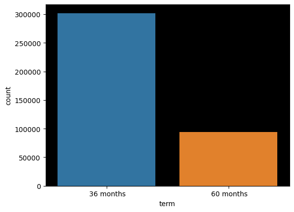

```python
sns.countplot(data=df, x=df['term'])
ax = plt.gca()
ax.set_facecolor("Black")
plt.show()
```

The graph illustrates the loan tenure options of 36 months and 60 months chosen by individuals. It is evident that the majority of individuals have opted for the 36-month tenure, while fewer have selected the 60-month tenure. Thus, we can infer that most people prefer the 36-month loan term based on the graph.

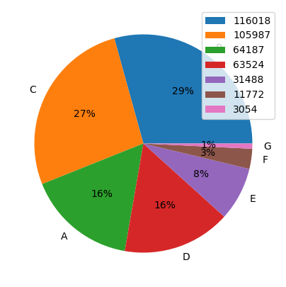

```python
plt.figure(figsize=(12,5))
plt.pie(df['grade'].value_counts(), labels=df['grade'].value_counts().index, autopct='%.0f%%')
plt.legend(labels=df['grade'].value_counts(), loc='upper right')
plt.show()
```

The graph displays the distribution of loan grades and the corresponding percentage of individuals categorized within each grade. It shows that the highest percentage of people are assigned the "B" grade, while the lowest percentage are assigned the "G" grade.

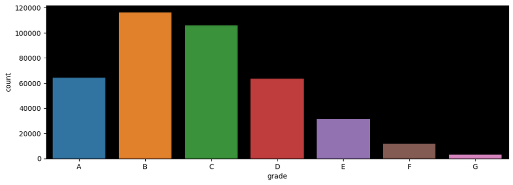

```python
plt.figure(figsize=(12,4))
sns.countplot(data=df, x=df['grade']);
ax = plt.gca()
ax.set_facecolor("Black")
```

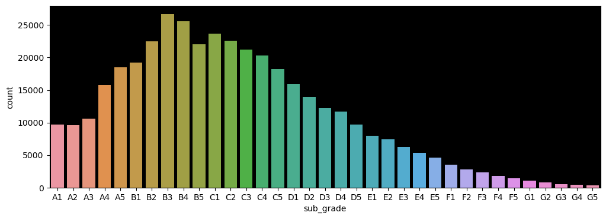

```python
plt.figure(figsize=(12,4))
sns.countplot(data=df ,x = df['sub_grade'])
ax = plt.gca()
ax.set_facecolor("Black")
plt.show()
```

Within the loan grades, LoanTap further subdivides them into subgrades. Notably, the subgrade "B" contains the largest number of instances, indicating that a significant portion of the population falls within this subcategory.

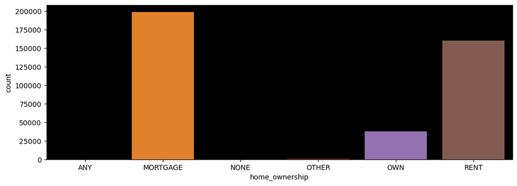

```python
plt.figure(figsize=(12,4))
sns.countplot(data=df ,x = df['home_ownership'])
ax = plt.gca()
ax.set_facecolor("Black")
plt.show()
```

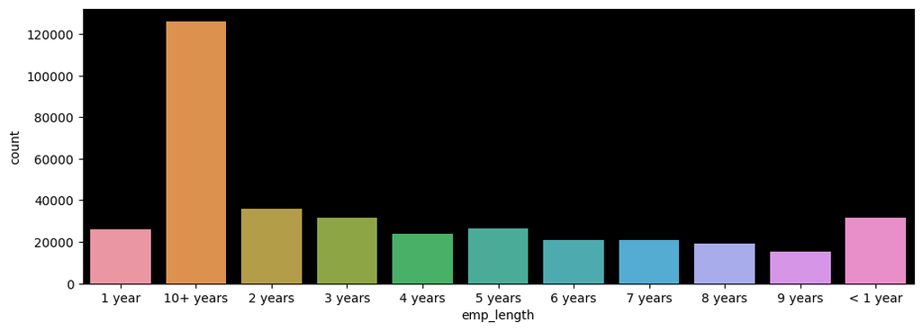

```python
plt.figure(figsize=(12,4))
sns.countplot(data=df ,x = df['emp_length'])
ax = plt.gca()
ax.set_facecolor("Black")
plt.show()
```

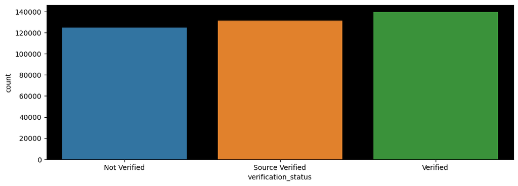

```python
plt.figure(figsize=(12,4))
sns.countplot(data=df ,x = df['verification_status'])
ax = plt.gca()
ax.set_facecolor("Black")
plt.show()
```

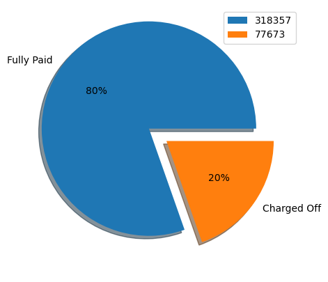

```python
plt.figure(figsize=(12,5))
plt.pie(df['loan_status'].value_counts(), labels=df['loan_status'].value_counts().index, autopct='%.0f%%',
        explode=[0.2,0],shadow=True)
plt.legend(labels=df['loan_status'].value_counts(), loc='upper right')
plt.show()
```

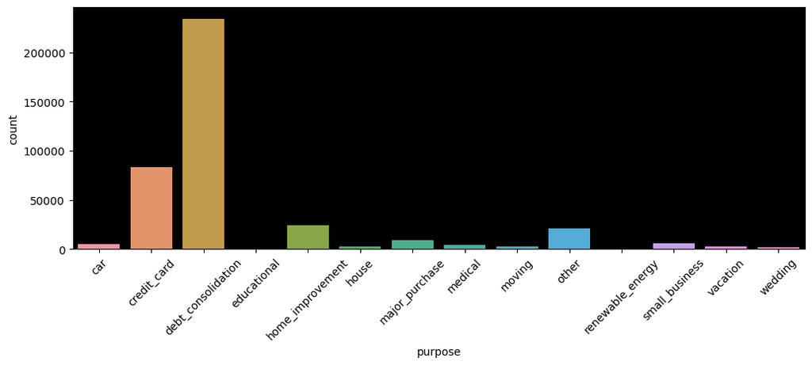

```python
plt.figure(figsize=(12,4))
sns.countplot(data=df ,x = df['purpose'])
ax = plt.gca()
ax.set_facecolor("Black")
plt.xticks(rotation = 45)
plt.show()
```

The graph reveals that the majority of individuals primarily use their cards for debt consolidation, with credit card usage following closely behind. This suggests that people are increasingly utilizing cards to manage and pay off their debts, indicating a focus on financial responsibility and fulfillment of financial needs.

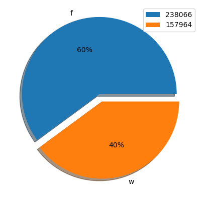

```python
plt.figure(figsize=(12,5))
plt.pie(df['initial_list_status'].value_counts(), labels=df['initial_list_status'].value_counts().index,
        autopct='%.0f%%', explode=[0.1,0],shadow=True)
plt.legend(labels=df['initial_list_status'].value_counts(), loc='upper right')
plt.show()
```

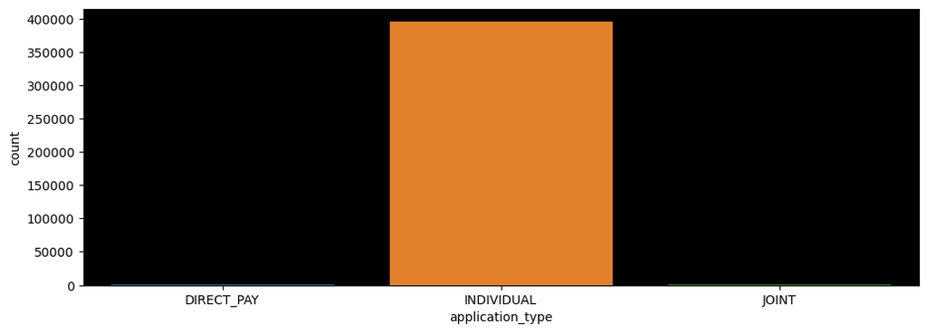

```python
plt.figure(figsize=(12,4))
sns.countplot(data=df ,x = df['application_type'])
ax = plt.gca()
ax.set_facecolor("Black")
plt.show()
```

```python
df['application_type'].value_counts(normalize=True)
```

```
INDIVIDUAL    0.998205
JOINT         0.001073
DIRECT_PAY    0.000722
Name: application_type, dtype: float64
```

# Bi-variate Analysis

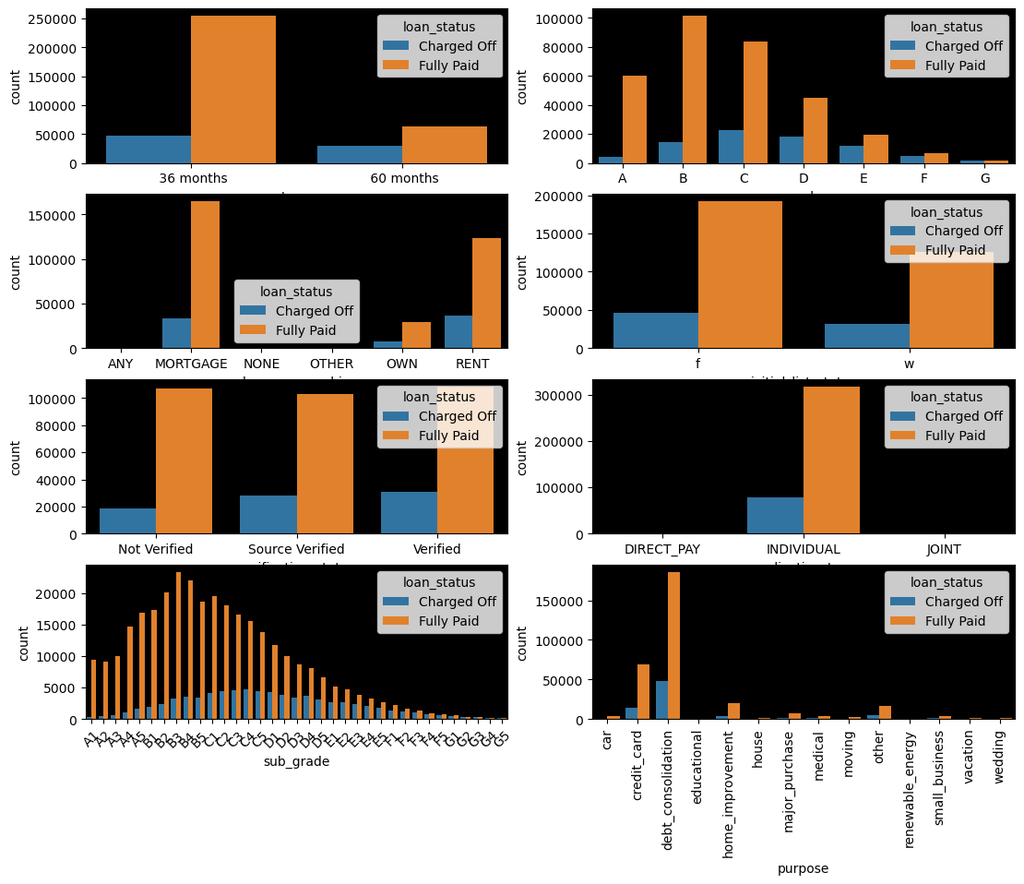

```python
plt.figure(figsize=(13,10))
plt.subplot(4,2,1)
sns.countplot(data=df, x='term', hue="loan_status")
plt.gca().set_facecolor("black");

plt.subplot(4,2,2)
sns.countplot(data=df, x='grade', hue="loan_status")
plt.gca().set_facecolor("black");

plt.subplot(4,2,3)
sns.countplot(data=df, x='home_ownership', hue="loan_status")
plt.gca().set_facecolor("black");

plt.subplot(4,2,4)
sns.countplot(data=df, x='initial_list_status', hue="loan_status")
plt.gca().set_facecolor("black");

plt.subplot(4,2,5)
sns.countplot(data=df, x='verification_status', hue="loan_status")
plt.gca().set_facecolor("black");

plt.subplot(4,2,6)
sns.countplot(data=df, x='application_type', hue="loan_status")
plt.gca().set_facecolor("black");

plt.subplot(4,2,7)
sns.countplot(data=df, x='sub_grade', hue="loan_status")
plt.xticks(rotation=45)
plt.gca().set_facecolor("black");

plt.subplot(4,2,8)
sns.countplot(data=df, x='purpose', hue="loan_status")
plt.xticks(rotation=90)
plt.gca().set_facecolor("black");
plt.show()
```

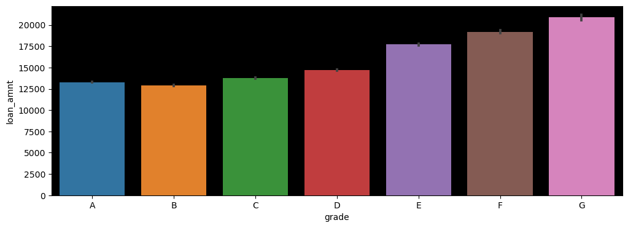

```python
plt.figure(figsize=(12,4))
sns.barplot(data=df, x=df['grade'], y=df['loan_amnt']);
ax = plt.gca()
ax.set_facecolor("Black")
```

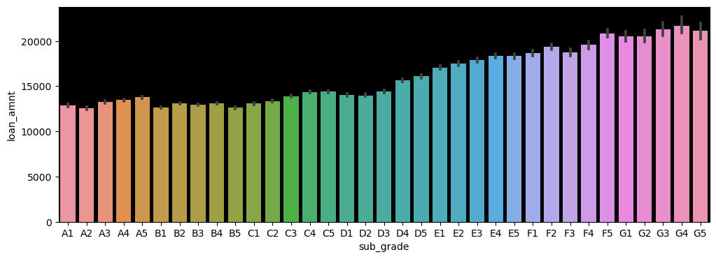

```python
plt.figure(figsize=(12,4))
sns.barplot(data=df, x=df['sub_grade'], y=df['loan_amnt']);
ax = plt.gca()
ax.set_facecolor("Black")
```

Based on the graph, it can be inferred that there is a saturation point across all subgrades, with the highest loan amounts observed in the "G" grade.

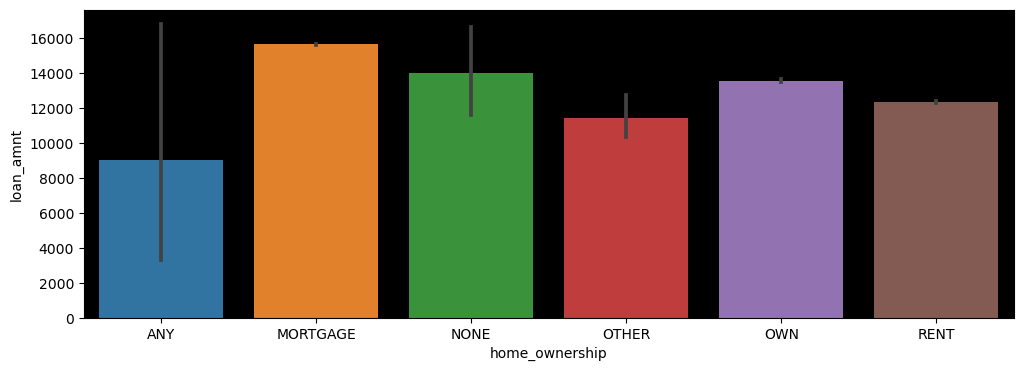

```python
plt.figure(figsize=(12,4))
sns.barplot(data=df, x=df['home_ownership'], y=df['loan_amnt']);
ax = plt.gca()
ax.set_facecolor("Black")
```

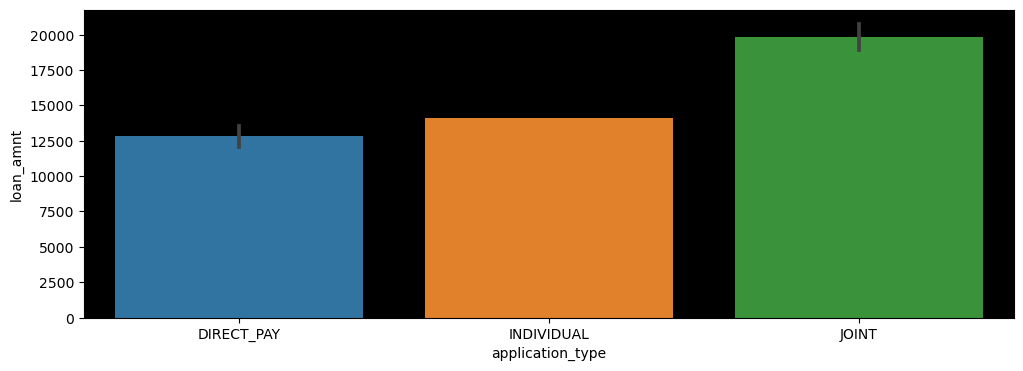

```python
plt.figure(figsize=(12,4))
sns.barplot(data=df, x=df['application_type'], y=df['loan_amnt']);
ax = plt.gca()
ax.set_facecolor("Black")
```

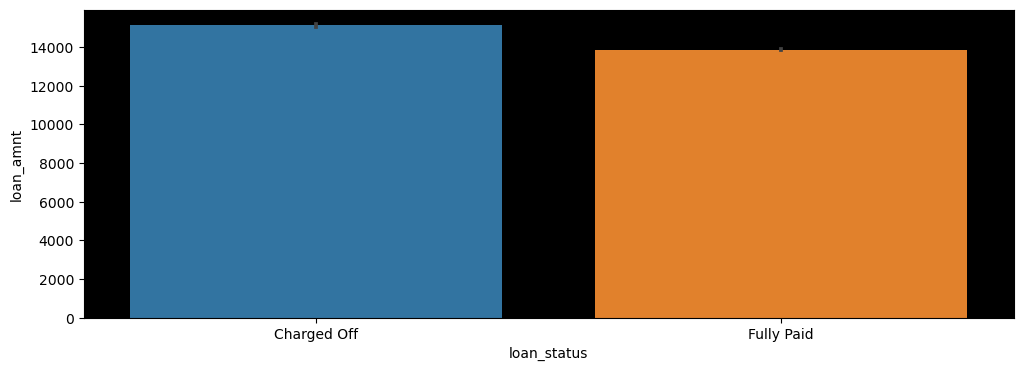

```python
plt.figure(figsize=(12,4))
sns.barplot(data=df, x=df['loan_status'], y=df['loan_amnt']);
ax = plt.gca()
ax.set_facecolor("Black")
```

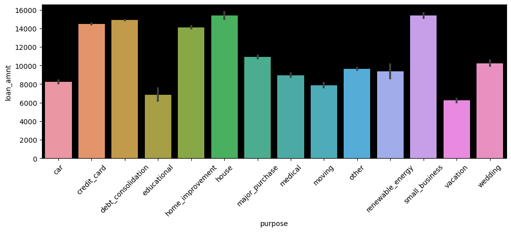

```python
plt.figure(figsize=(12,4))
sns.barplot(data=df, x=df['purpose'], y=df['loan_amnt'])
ax = plt.gca()
ax.set_facecolor("Black")
plt.xticks(rotation =45)
plt.show()
```

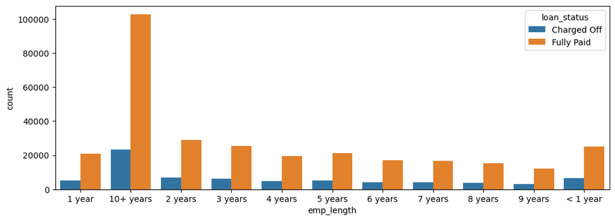

```python
plt.figure(figsize=(12,4))
sns.countplot(x= df['emp_length'], hue=df['loan_status']);
```

```python
df.columns
```

```
Index(['loan_amnt', 'term', 'int_rate', 'installment', 'grade', 'sub_grade',
       'emp_length', 'home_ownership', 'annual_inc', 'verification_status',
       'loan_status', 'purpose', 'dti', 'open_acc', 'pub_rec', 'revol_bal',
       'revol_util', 'total_acc', 'initial_list_status', 'application_type',
       'mort_acc', 'pub_rec_bankruptcies', 'earliest_year', 'pin_code',
       'issue_d_year'],
      dtype='object')
```

```python
# plt.figure(figsize=(12,5))
# plt.barh(df["emp_title"].value_counts()[:20].index,df["emp_title"].value_counts()[:20]);
```

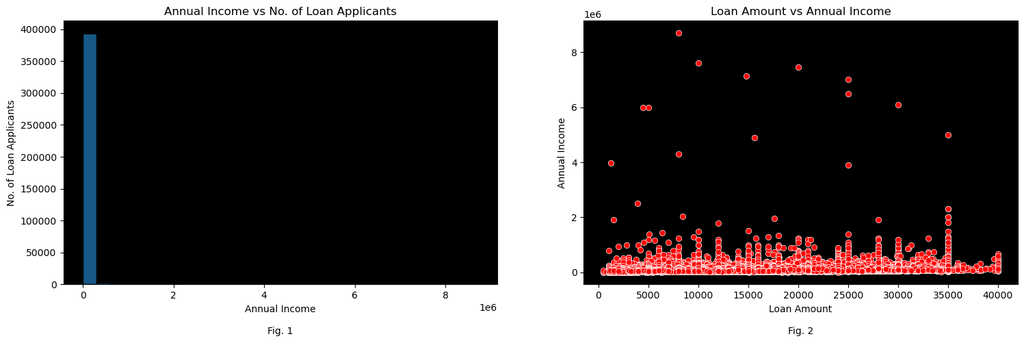

```python
plt.figure(figsize=(18,5))

plt.subplot(1, 2, 1)
sns.histplot(data=df, x='annual_inc', bins=30)
plt.xlabel(f'Annual Income\n\nFig. 1')
plt.ylabel('No. of Loan Applicants')
plt.title('Annual Income vs No. of Loan Applicants')
plt.gca().set_facecolor("black")

plt.subplot(1, 2, 2)
sns.scatterplot(x = df['loan_amnt'], y = df['annual_inc'], c='red')
plt.xlabel(f'Loan Amount\n\nFig. 2')
plt.ylabel('Annual Income')
plt.title('Loan Amount vs Annual Income')
plt.gca().set_facecolor("black")
plt.show()
```

In Figure 1, it is noticeable that the majority of applicants have an income of approximately less than $300,000 per year, with only a small number of applicants reporting very high incomes. This trend is also evident in Figure 2, where data points are densely clustered at the lower end, with only a few points scattered sparsely above. These scattered points, known as outliers, pose a risk of biasing the results of our modeling predictions. Therefore, it is advisable to remove these outliers from the dataset to ensure the accuracy and reliability of our analysis.

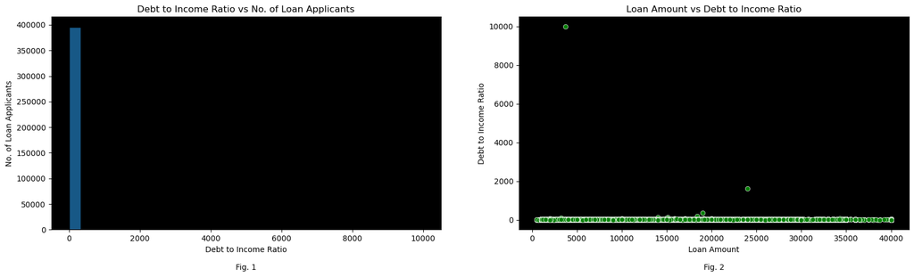

```python
plt.figure(figsize=(20,5))


plt.subplot(1, 2, 1)
sns.histplot(data=df, x='dti', bins=30)
plt.xlabel(f'Debt to Income Ratio\n\nFig. 1')
plt.ylabel('No. of Loan Applicants')
plt.title('Debt to Income Ratio vs No. of Loan Applicants')
plt.gca().set_facecolor("black")



plt.subplot(1, 2, 2)
sns.scatterplot(x = df['loan_amnt'], y = df['dti'], c='green')
plt.xlabel(f'Loan Amount\n\nFig. 2')
plt.ylabel('Debt to Income Ratio')
plt.title('Loan Amount vs Debt to Income Ratio')
plt.gca().set_facecolor("black")
```

Figure 1 illustrates that the majority of applicants have a debt-to-income ratio of approximately less than 50, with only a small number reporting very high ratios. This pattern is also evident in Figure 2, where most data points are tightly clustered at the lower end, while only a few points are scattered more widely above. These scattered points, referred to as outliers, pose a risk of biasing the results of our modeling predictions. Therefore, it is advisable to eliminate these outliers from the dataset to ensure the accuracy and reliability of our analysis.

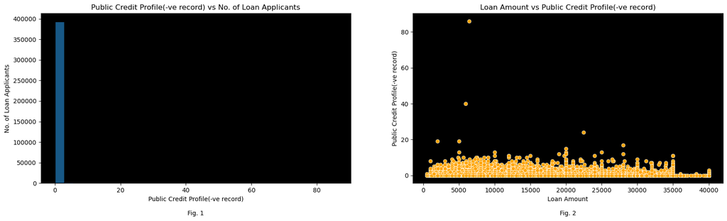

```python
plt.figure(figsize=(20,5))

plt.subplot(1, 2, 1)
sns.histplot(data=df, x='pub_rec', bins=30)
plt.xlabel(f'Public Credit Profile(-ve record)\n\nFig. 1')
plt.ylabel('No. of Loan Applicants')
plt.title('Public Credit Profile(-ve record) vs No. of Loan Applicants')
plt.gca().set_facecolor("black")


plt.subplot(1, 2, 2)
sns.scatterplot(x = df['loan_amnt'], y = df['pub_rec'], c='orange')
plt.xlabel(f'Loan Amount\n\nFig. 2')
plt.ylabel('Public Credit Profile(-ve record)')
plt.title('Loan Amount vs Public Credit Profile(-ve record)')
plt.gca().set_facecolor("black")
plt.show()
```

### Checking for the Outliers in Data features

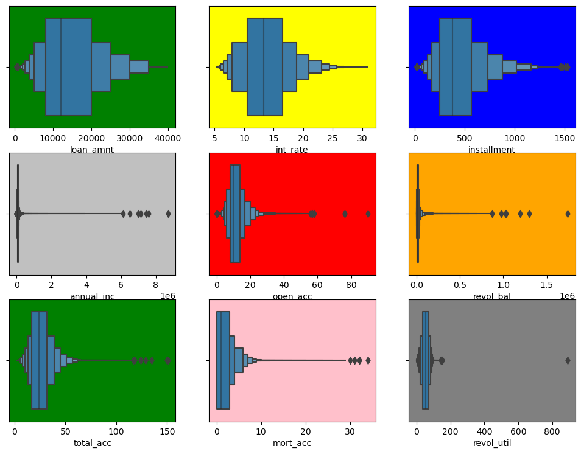

```python
plt.figure(figsize=(12,12))
plt.subplot(4,3,1)
sns.boxenplot(data=df, x=df['loan_amnt'])
plt.gca().set_facecolor("green")

plt.subplot(4,3,2)
sns.boxenplot(data=df, x=df['int_rate'])
plt.gca().set_facecolor("yellow")


plt.subplot(4,3,3)
sns.boxenplot(data=df, x=df['installment'])
plt.gca().set_facecolor("blue")


plt.subplot(4,3,4)
sns.boxenplot(data=df, x=df['annual_inc'])
plt.gca().set_facecolor("silver")


plt.subplot(4,3,5)
sns.boxenplot(data=df, x=df['open_acc'])
plt.gca().set_facecolor("red")


plt.subplot(4,3,6)
sns.boxenplot(data=df, x=df['revol_bal'])
plt.gca().set_facecolor("orange")


plt.subplot(4,3,7)
sns.boxenplot(data=df, x=df['total_acc'])
plt.gca().set_facecolor("green")


plt.subplot(4,3,8)
sns.boxenplot(data=df, x=df['mort_acc'])
plt.gca().set_facecolor("pink")


plt.subplot(4,3,9)
sns.boxenplot(data=df, x=df['revol_util'])
plt.gca().set_facecolor("gray")

plt.show()
```